# Comparison of human and LLM humor comprehension

Drew Walker, Sean Trott, Seana Coulson

July 17, 2023

# Load data

## LLM data

### Load 0-shot probes

```r
## setwd("/Users/seantrott/Dropbox/UCSD/Research/NLMs/humor_llms/src/analysis")
df_0s = read_csv("../../data/processed/comprehension_probe_0shot.csv")
nrow(df_0s)
```

```
## [1] 400
```

```r
head(df_0s)
```

```
## # A tibble: 6 × 9
##   model            sentence answer shots condi…¹ correct yes_lp    no_lp lp_ra…²
##   <chr>            <chr>    <chr>  <dbl> <chr>   <chr>    <dbl>    <dbl>   <dbl>
## 1 text-davinci-002 A commi… Commi…     0 J       no      -6.00   -0.0499  -5.95
## 2 text-davinci-002 A commi… Commi…     0 S       yes     -0.328  -6.39     6.06
## 3 text-davinci-002 A devic… The c…     0 S       yes     -0.631  -7.96     7.33
## 4 text-davinci-002 A devic… Peopl…     0 J       yes     -3.03   -0.409   -2.62
## 5 text-davinci-002 A good … Carro…     0 E       yes     -0.295 -10.1      9.78
## 6 text-davinci-002 A good … An ex…     0 J       yes     -1.22   -1.40     0.183
## # … with abbreviated variable names ¹condition, ²lp_ratio
```

### Load 1-shot probes

```r
## setwd("/Users/seantrott/Dropbox/UCSD/Research/NLMs/humor_llms/src/analysis")
df_1s = read_csv("../../data/processed/comprehension_probe_1shot.csv")
nrow(df_1s)
```

```
## [1] 400
```

```r
head(df_1s)
```

```
## # A tibble: 6 × 9
##   model           sente…¹ answer shots condi…² correct   yes_lp    no_lp lp_ra…³
##   <chr>           <chr>   <chr>  <dbl> <chr>   <chr>      <dbl>    <dbl>   <dbl>
## 1 text-davinci-0… A comm… Commi…     1 J       no      -11.4    -5.54e-3 -11.4
## 2 text-davinci-0… A comm… Commi…     1 S       yes      -0.0293 -5.00e+0   4.97
## 3 text-davinci-0… A devi… The c…     1 S       yes      -0.131  -5.34e+0   5.21
## 4 text-davinci-0… A devi… Peopl…     1 J       yes      -0.848  -1.03e+0   0.185
## 5 text-davinci-0… A good… Carro…     1 E       yes      -0.131  -1.17e+1  11.5
## 6 text-davinci-0… A good… An ex…     1 J       yes      -0.814  -1.17e+0   0.358
## # … with abbreviated variable names ¹sentence, ²condition, ³lp_ratio
```

## Human data

```r
df_cleaned = read_csv("../../data/processed/human_data/comprehension_cleaned_final.csv")
nrow(df_cleaned)
```

```
## [1] 10112
```

```r
head(df_cleaned)
```

```
## # A tibble: 6 × 14
##   ParticipantID  Trial…¹ Respo…² React…³ Sente…⁴ Targe…⁵ Surpr…⁶ NumTo…⁷ LastE…⁸
##   <chr>            <dbl> <chr>     <dbl> <chr>   <chr>     <dbl>   <dbl>   <dbl>
## 1 5ef3fff5be34b…       1 YES       1633. The wh… speak      3.91       1    5025
## 2 5ef3fff5be34b…       2 YES       9242. The co… bathtub    9.09       2    2038
## 3 5ef3fff5be34b…       3 YES       1666. Love h… alimony   18.9        2    1150
## 4 5ef3fff5be34b…       4 NO        1684. He own… statem…    8.74       1    4011
## 5 5ef3fff5be34b…       5 NO        1317. The po… litter…    9.59       2    5026
## 6 5ef3fff5be34b…       6 YES       3997. A thou… working    8.05       1    3003
## # … with 5 more variables: StimType <chr>, CounterBalance <chr>,
## #   ComprehensionQuestion <chr>, CorrectAnswer <chr>, Match <dbl>, and
## #   abbreviated variable names ¹TrialNumber, ²Response, ³ReactionTime,
## #   ⁴Sentence, ⁵TargetWords, ⁶Surprisal, ⁷NumTokens, ⁸LastEventCode
## # ℹ Use `colnames()` to see all variable names
```

```r
length(unique(df_cleaned$ParticipantID))
```

```
## [1] 158
```

### Exclusions

No participants failed the catch trials.

```r
table(df_cleaned$StimType)
```

```
##
##    catch expected     joke straight
##      632     3160     3160     3160
```

```r
df_passed_attention = df_cleaned %>%
  filter(StimType == "catch") %>%
  group_by(ParticipantID) %>%
  summarise(accuracy = mean(Match))

nrow(df_passed_attention)
```

```
## [1] 158
```

```r
df_cleaned = df_cleaned %>%
  filter(ParticipantID %in% df_passed_attention$ParticipantID)

nrow(df_cleaned)
```

```
## [1] 10112
```

### Remove catch trials

```r
df_critical = df_cleaned %>%
  filter(StimType != "catch")

table(df_critical$StimType)
```

```
##
## expected     joke straight
##     3160     3160     3160
```

# Analysis of human data

First, we conduct an analysis of the human data alone.

## Effect of `CorrectAnswer`?

First, we need to establish whether accuracy is higher for “yes” or “no” responses to determine whether to include `CorrectAnswer` in our model as a covariate.

There is no evidence of an interaction between `StimType` and `CorrectAnswer`.

```r
mod_full = glmer(data = df_critical,
                 Match ~ StimType * CorrectAnswer + (1 | ParticipantID) +
                   (1 | Sentence),
                 family = binomial())

mod_just_me = glmer(data = df_critical,
                 Match ~ StimType + CorrectAnswer + (1 | ParticipantID) +
                   (1 | Sentence),
                 family = binomial())

anova(mod_full, mod_just_me)
```

```
## Data: df_critical
## Models:
## mod_just_me: Match ~ StimType + CorrectAnswer + (1 | ParticipantID) + (1 | Sentence)
## mod_full: Match ~ StimType * CorrectAnswer + (1 | ParticipantID) + (1 | Sentence)
##             npar    AIC    BIC  logLik deviance  Chisq Df Pr(>Chisq)
## mod_just_me    6 5593.9 5636.8 -2790.9   5581.9
## mod_full       8 5597.4 5654.7 -2790.7   5581.4 0.4221  2     0.8098
```

The effect of `CorrectAnswer` is trending ($p = .06$).

```r
mod_just_stimtype = glmer(data = df_critical,
                 Match ~ StimType + (1 | ParticipantID) +
                   (1 | Sentence),
                 family = binomial())

anova(mod_just_me, mod_just_stimtype)
```

```
## Data: df_critical
## Models:
## mod_just_stimtype: Match ~ StimType + (1 | ParticipantID) + (1 | Sentence)
## mod_just_me: Match ~ StimType + CorrectAnswer + (1 | ParticipantID) + (1 | Sentence)
##                   npar    AIC    BIC  logLik deviance  Chisq Df Pr(>Chisq)
## mod_just_stimtype    5 5595.2 5631.0 -2792.6   5585.2
## mod_just_me          6 5593.9 5636.8 -2790.9   5581.9 3.3462  1    0.06736 .
## ---
## Signif. codes:  0 '***' 0.001 '**' 0.01 '*' 0.05 '.' 0.1 ' ' 1
```

Accuracy is slightly higher for “no” responses than “yes” responses:

```r
df_critical %>%
  group_by(CorrectAnswer) %>%
  summarise(accuracy = mean(Match))
```

```
## # A tibble: 2 × 2
##   CorrectAnswer accuracy
##   <chr>            <dbl>
## 1 no               0.903
## 2 yes              0.887
```

## Effect of `StimType`?

Our primary question is whether accuracy is lower for jokes than the other two conditions.

The model comparison suggests there is.

```r
mod_just_stimtype = glmer(data = df_critical,
                 Match ~ StimType + (1 | ParticipantID) +
                   (1 | Sentence),
                 family = binomial(),
                 control=glmerControl(optimizer="bobyqa"))

mod_null = glmer(data = df_critical,
                 Match ~ (1 | ParticipantID) +
                   (1 | Sentence),
                 family = binomial(),
                 control=glmerControl(optimizer="bobyqa"))

anova(mod_just_stimtype, mod_null)
```

```
## Data: df_critical
## Models:
## mod_null: Match ~ (1 | ParticipantID) + (1 | Sentence)
## mod_just_stimtype: Match ~ StimType + (1 | ParticipantID) + (1 | Sentence)
##                   npar    AIC  BIC  logLik deviance  Chisq Df Pr(>Chisq)
## mod_null             3 5625.5 5647 -2809.8   5619.5
## mod_just_stimtype    5 5595.2 5631 -2792.6   5585.2 34.333  2  3.505e-08 ***
## ---
## Signif. codes:  0 '***' 0.001 '**' 0.01 '*' 0.05 '.' 0.1 ' ' 1
```

```r
summary(mod_just_stimtype)
```

```
## Generalized linear mixed model fit by maximum likelihood (Laplace
##   Approximation) [glmerMod]
##  Family: binomial  ( logit )
## Formula: Match ~ StimType + (1 | ParticipantID) + (1 | Sentence)
##    Data: df_critical
## Control: glmerControl(optimizer = "bobyqa")
##
##      AIC      BIC   logLik deviance df.resid
##   5595.2   5631.0  -2792.6   5585.2     9475
##
## Scaled residuals:
##     Min      1Q  Median      3Q     Max
## -6.9455  0.1545  0.2185  0.3128  3.0438
##
## Random effects:
##  Groups        Name        Variance Std.Dev.
##  Sentence      (Intercept) 1.0797   1.0391
##  ParticipantID (Intercept) 0.6637   0.8147
## Number of obs: 9480, groups:  Sentence, 400; ParticipantID, 158
##
## Fixed effects:
##                  Estimate Std. Error z value Pr(>|z|)
## (Intercept)        3.1372     0.1614  19.442  < 2e-16 ***
## StimTypejoke      -0.8827     0.1761  -5.012 5.38e-07 ***
## StimTypestraight  -0.1186     0.1819  -0.652    0.514
## ---
## Signif. codes:  0 '***' 0.001 '**' 0.01 '*' 0.05 '.' 0.1 ' ' 1
##
## Correlation of Fixed Effects:
##             (Intr) StmTypj
## StimTypejok -0.726
## StmTypstrgh -0.692  0.638
```

Specifically, accuracy is lower for jokes than expected or straight stimuli.

```r
df_critical %>%
  group_by(StimType) %>%
  summarize(accuracy = mean(Match))
```

```
## # A tibble: 3 × 2
##   StimType accuracy
##   <chr>       <dbl>
## 1 expected    0.922
## 2 joke        0.847
## 3 straight    0.916
```

We can visualize this result:

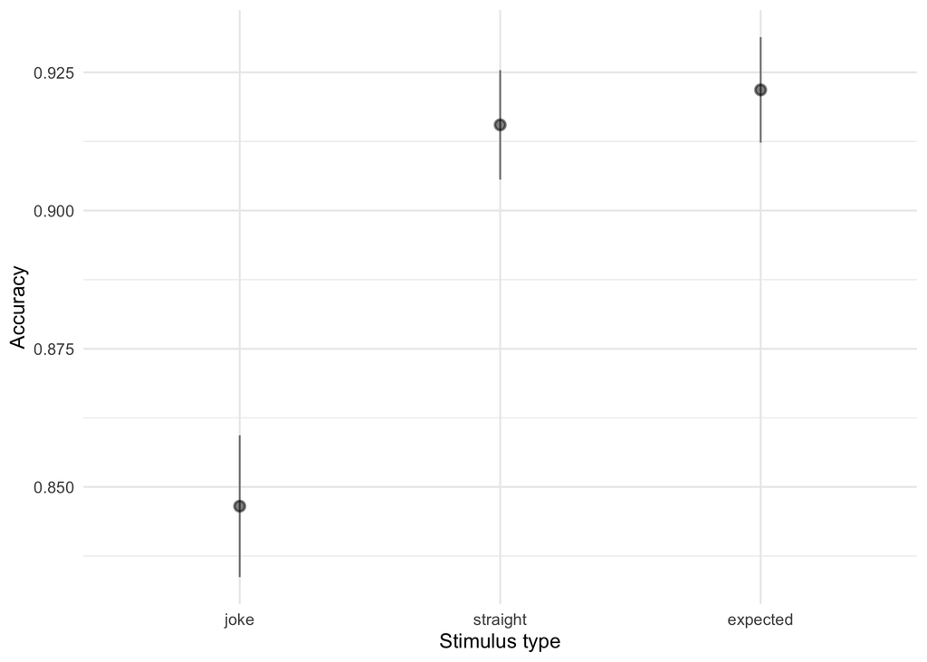

```r
df_critical %>%
  ggplot(aes(x = reorder(StimType, Match),
             y = Match)) +
  stat_summary (fun = function(x){mean(x)},
                fun.min = function(x){mean(x) - 2*sd(x)/sqrt(length(x))},
                fun.max = function(x){mean(x) + 2*sd(x)/sqrt(length(x))},
                geom= 'pointrange',
                position=position_dodge(width=0.95),
                size = .5, alpha = .5) +
  labs(x = "Stimulus type",
       y = "Accuracy") +
  # scale_y_continuous(limits = c(0, 1)) +
  # geom_hline(yintercept = .5, linetype = "dotted") +
  theme_minimal()
```

# Comparing human and LLM data

Now, we compare human and LLM humor comprehension.

We do this with two approaches:

1. In the first approach, we focus on the difference between human and LLM performance, i.e., the `Source` of a given response.
2. In the second approach, we ask to what extent human behavior can be explained as a function of LLM behavior.

## Step 1: Merging data

### Merging approach 1

Here, we “stack” the dataframes.

```r
df_llm = df_0s %>%
  mutate(StimType = case_when(
    condition == "J" ~ "joke",
    condition == "E" ~ "expected",
    condition == "S" ~ "straight"
  )) %>%
  mutate(Sentence = sentence,
         ComprehensionQuestion = answer,
         CorrectAnswer = correct
         ) %>%
  mutate(Match = case_when(
    correct == "yes" & lp_ratio > 0 ~ 1,
    correct == "no" & lp_ratio < 0 ~ 1,
    correct == "yes" & lp_ratio < 0 ~ 0,
    correct == "no" & lp_ratio > 0 ~ 0
  )) %>%
  select(Sentence, ComprehensionQuestion, StimType, CorrectAnswer, Match) %>%
  mutate(Source = "LLM")

df_merged_stacked = df_critical %>%
  mutate(Sentence = paste(Sentence, ".", sep = "")) %>%
  mutate(Source = "Human") %>%
  bind_rows(df_llm)
```

### Merging approach 2

Here, we merge the data to include the **log-odds** from GPT-3.

```r
df_llm2 = df_0s %>%
  mutate(StimType = case_when(
    condition == "J" ~ "joke",
    condition == "E" ~ "expected",
    condition == "S" ~ "straight"
  )) %>%
  mutate(Sentence = sentence,
         ComprehensionQuestion = answer,
         CorrectAnswer = correct
         ) %>%
  select(Sentence, StimType, CorrectAnswer, condition, lp_ratio)

df_merged_joined = df_critical %>%
  mutate(Sentence = paste(Sentence, ".", sep = "")) %>%
  select(Sentence, StimType, CorrectAnswer, Match, Response, ReactionTime, ParticipantID) %>%
  left_join(df_llm2, by = c("Sentence", "StimType", "CorrectAnswer"))

nrow(df_merged_joined)
```

```
## [1] 9480
```

## Match ~ Source

Here, we ask whether humans or LLMs are more likely to answer correctly.

```r
mod_just_source = glmer(data = df_merged_stacked,
                 Match ~ Source +
                   (1 | Sentence),
                 family = binomial(),
                 control=glmerControl(optimizer="bobyqa"))

mod_no_source = glmer(data = df_merged_stacked,
                 Match ~ # Source +
                   (1 | Sentence),
                 family = binomial(),
                 control=glmerControl(optimizer="bobyqa"))

anova(mod_just_source, mod_no_source)
```

```
## Data: df_merged_stacked
## Models:
## mod_no_source: Match ~ (1 | Sentence)
## mod_just_source: Match ~ Source + (1 | Sentence)
##                 npar    AIC    BIC  logLik deviance  Chisq Df Pr(>Chisq)
## mod_no_source      2 6279.1 6293.5 -3137.5   6275.1
## mod_just_source    3 6272.2 6293.8 -3133.1   6266.2 8.8977  1   0.002855 **
## ---
## Signif. codes:  0 '***' 0.001 '**' 0.01 '*' 0.05 '.' 0.1 ' ' 1
```

There does appear to be a main effect of `Source`:

```r
df_merged_stacked %>%
  group_by(Source) %>%
  summarise(accuracy = mean(Match))
```

```
## # A tibble: 2 × 2
##   Source accuracy
##   <chr>     <dbl>
## 1 Human     0.895
## 2 LLM       0.842
```

We can visualize this by comparing LLM accuracy to the distribution of by-subject accuracies:

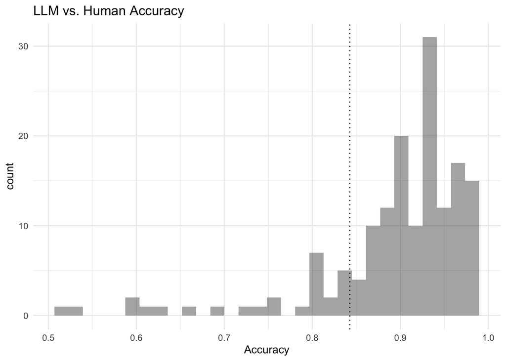

```r
df_by_subj = df_critical %>%
  group_by(ParticipantID) %>%
  summarise(accuracy = mean(Match))

llm_accuracy = mean(df_llm$Match)

df_by_subj %>%
  ggplot(aes(x = accuracy)) +
  geom_histogram(alpha = .5) +
  geom_vline(xintercept = llm_accuracy, linetype = "dotted") +
  theme_minimal() +
  labs(x = "Accuracy",
       title = "LLM vs. Human Accuracy")
```

## Match ~ Source + IsJoke

```r
df_merged_stacked = df_merged_stacked %>%
  mutate(IsJoke = StimType == "joke")
```

Yes, `IsJoke` does continue to explain variance even once we account for `Source`.

```r
mod_just_src_isjoke_me = glmer(data = df_merged_stacked,
                 Match ~ Source + IsJoke +
                   (1 | Sentence),
                 family = binomial(),
                 control=glmerControl(optimizer="bobyqa"))

anova(mod_just_src_isjoke_me, mod_just_source)
```

```
## Data: df_merged_stacked
## Models:
## mod_just_source: Match ~ Source + (1 | Sentence)
## mod_just_src_isjoke_me: Match ~ Source + IsJoke + (1 | Sentence)
##                        npar    AIC    BIC  logLik deviance Chisq Df Pr(>Chisq)
## mod_just_source           3 6272.2 6293.8 -3133.1   6266.2
## mod_just_src_isjoke_me    4 6231.5 6260.3 -3111.8   6223.5 42.65  1  6.548e-11
##
## mod_just_source
## mod_just_src_isjoke_me ***
## ---
## Signif. codes:  0 '***' 0.001 '**' 0.01 '*' 0.05 '.' 0.1 ' ' 1
```

## Match ~ Source x StimType

Moreover, there is an **interaction**: the joke vs. non-joke gulf is bigger for LLMs.

```r
mod_src_stimtype = glmer(data = df_merged_stacked,
                 Match ~ Source * IsJoke +
                   (1 | Sentence),
                 family = binomial(),
                 control=glmerControl(optimizer="bobyqa"))

anova(mod_just_src_isjoke_me, mod_src_stimtype)
```

```
## Data: df_merged_stacked
## Models:
## mod_just_src_isjoke_me: Match ~ Source + IsJoke + (1 | Sentence)
## mod_src_stimtype: Match ~ Source * IsJoke + (1 | Sentence)
##                        npar    AIC    BIC  logLik deviance  Chisq Df Pr(>Chisq)
## mod_just_src_isjoke_me    4 6231.5 6260.3 -3111.8   6223.5
## mod_src_stimtype          5 6214.3 6250.3 -3102.2   6204.3 19.205  1  1.174e-05
##
## mod_just_src_isjoke_me
## mod_src_stimtype       ***
## ---
## Signif. codes:  0 '***' 0.001 '**' 0.01 '*' 0.05 '.' 0.1 ' ' 1
```

```r
summary(mod_src_stimtype)
```

```
## Generalized linear mixed model fit by maximum likelihood (Laplace
##   Approximation) [glmerMod]
##  Family: binomial  ( logit )
## Formula: Match ~ Source * IsJoke + (1 | Sentence)
##    Data: df_merged_stacked
## Control: glmerControl(optimizer = "bobyqa")
##
##      AIC      BIC   logLik deviance df.resid
##   6214.3   6250.3  -3102.2   6204.3     9875
##
## Scaled residuals:
##     Min      1Q  Median      3Q     Max
## -5.0647  0.1943  0.2458  0.3378  2.0652
##
## Random effects:
##  Groups   Name        Variance Std.Dev.
##  Sentence (Intercept) 0.8768   0.9364
## Number of obs: 9880, groups:  Sentence, 400
##
## Fixed effects:
##                      Estimate Std. Error z value Pr(>|z|)
## (Intercept)           2.75007    0.08501  32.351  < 2e-16 ***
## SourceLLM             0.39243    0.28725   1.366    0.172
## IsJokeTRUE           -0.74542    0.12423  -6.000 1.97e-09 ***
## SourceLLM:IsJokeTRUE -1.43016    0.34728  -4.118 3.82e-05 ***
## ---
## Signif. codes:  0 '***' 0.001 '**' 0.01 '*' 0.05 '.' 0.1 ' ' 1
##
## Correlation of Fixed Effects:
##             (Intr) SrcLLM IJTRUE
## SourceLLM   -0.095
## IsJokeTRUE  -0.637  0.066
## SLLM:IJTRUE  0.071 -0.827 -0.124
```

The descriptive stats are as follows:

```r
df_merged_stacked %>%
  group_by(IsJoke, Source) %>%
  summarise(accuracy = mean(Match))
```

```
## # A tibble: 4 × 3
## # Groups:   IsJoke [2]
##   IsJoke Source accuracy
##   <lgl>  <chr>     <dbl>
## 1 FALSE  Human     0.919
## 2 FALSE  LLM       0.942
## 3 TRUE   Human     0.847
## 4 TRUE   LLM       0.694
```

We can also visualize the raw data, which suggests a cross-over interaction. LLMs are better for non-jokes, and humans are (relatively) better for jokes. Both LLMs and humans are worse at jokes, however.

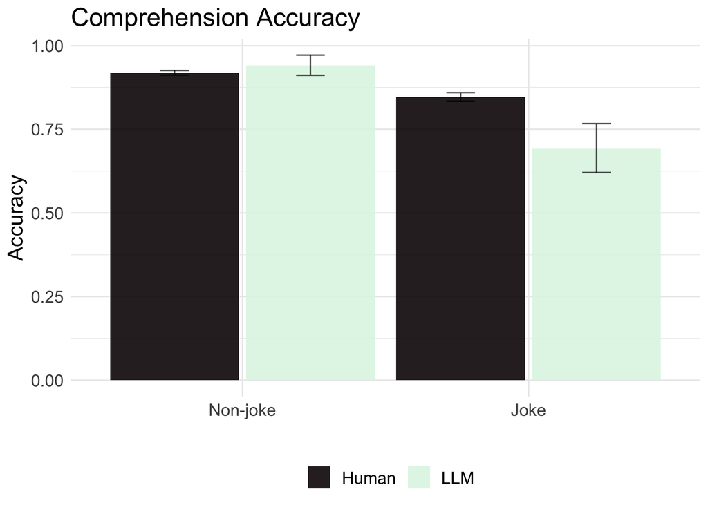

```r
df_merged_stacked = df_merged_stacked %>%
  mutate(is_joke = case_when(
    IsJoke == TRUE ~ "Joke",
    IsJoke == FALSE ~ "Non-joke"
  ))
df_merged_stacked$is_joke = factor(df_merged_stacked$is_joke, levels=c("Non-joke", "Joke"))

df_merged_stacked %>%
  ggplot(aes(x = is_joke,
             y = Match,
             fill = Source)) +
  stat_summary (fun = function(x){mean(x)},
                geom = "col",
                position=position_dodge(width=0.95),
                size = .5, alpha = .9) +
  stat_summary (fun = function(x){mean(x)},
                geom = "errorbar",
                fun.min = function(x){mean(x) - 2*sd(x)/sqrt(length(x))},
                fun.max = function(x){mean(x) + 2*sd(x)/sqrt(length(x))},
                position=position_dodge(width=0.95),
                width = .2, alpha = .7) +
  labs(x = "",
       y = "Accuracy",
       fill = "",
       title = "Comprehension Accuracy") +
  # scale_y_continuous(limits = c(0, 1)) +
  # geom_hline(yintercept = .5, linetype = "dotted") +
    theme_minimal() +
  theme(text = element_text(size = 15),
        legend.position="bottom") +
   scale_fill_viridis(option = "mako", discrete=TRUE)
```

## Match ~ Log Odds

Item-level variance in Log-odds does not appear to be related to the probability of humans getting a correct response.

```r
mod_full = glmer(data = df_merged_joined,
                 Match ~ StimType * CorrectAnswer + lp_ratio +
                   (1 | ParticipantID) +
                   (1 | Sentence),
                 family = binomial(),
                 control=glmerControl(optimizer="bobyqa"))

mod_no_lp = glmer(data = df_merged_joined,
                 Match ~ StimType * CorrectAnswer + # + lp_ratio +
                   (1 | ParticipantID) +
                   (1 | Sentence),
                 family = binomial(),
                 control=glmerControl(optimizer="bobyqa"))

anova(mod_full, mod_no_lp)
```

```
## Data: df_merged_joined
## Models:
## mod_no_lp: Match ~ StimType * CorrectAnswer + (1 | ParticipantID) + (1 | Sentence)
## mod_full: Match ~ StimType * CorrectAnswer + lp_ratio + (1 | ParticipantID) + (1 | Sentence)
##           npar    AIC    BIC  logLik deviance  Chisq Df Pr(>Chisq)
## mod_no_lp    8 5597.4 5654.7 -2790.7   5581.4
## mod_full     9 5597.6 5662.0 -2789.8   5579.6 1.8431  1     0.1746
```

# Exploratory analyses

## t-test comparison

Because the mixed models analyzing `Source` could not account for `ParticipantID`, we could not account for that source of non-independence. Here, we run a series of simpler t-tests to ask the same questions.

The one-sample t-tests are consistent with the results above, namely that humans do better on jokes and LLMs do better on non-jokes.

```r
df_summ_humans = df_merged_stacked %>%
  filter(Source == "Human") %>%
  group_by(ParticipantID, IsJoke) %>%
  summarise(accuracy = mean(Match))
llm_joke_accuracy = df_merged_stacked %>%
  filter(Source == "LLM") %>%
  filter(IsJoke == TRUE) %>%
  summarise(accuracy = mean(Match)) %>%
  pull()
llm_joke_accuracy
```

```
## [1] 0.69375
```

```r
## Yes, t-test comparing human joke accuracy to LLM Joke accuracy is significant
t.test(filter(df_summ_humans, IsJoke == TRUE)$accuracy, mu = llm_joke_accuracy)
```

```
##
##  One Sample t-test
##
## data:  filter(df_summ_humans, IsJoke == TRUE)$accuracy
## t = 15.846, df = 157, p-value < 2.2e-16
## alternative hypothesis: true mean is not equal to 0.69375
## 95 percent confidence interval:
##  0.8274766 0.8655614
## sample estimates:
## mean of x
##  0.846519
```

```r
llm_nj_accuracy = df_merged_stacked %>%
  filter(Source == "LLM") %>%
  filter(IsJoke == FALSE) %>%
  summarise(accuracy = mean(Match)) %>%
  pull()
llm_nj_accuracy
```

```
## [1] 0.9416667
```

```r
## Yes, t-test comparing human non-joke accuracy to LLM non-joke accuracy is significant
t.test(filter(df_summ_humans, IsJoke == FALSE)$accuracy, mu = llm_nj_accuracy)
```

```
##
##  One Sample t-test
##
## data:  filter(df_summ_humans, IsJoke == FALSE)$accuracy
## t = -3.4397, df = 157, p-value = 0.000746
## alternative hypothesis: true mean is not equal to 0.9416667
## 95 percent confidence interval:
##  0.9054661 0.9318757
## sample estimates:
## mean of x
## 0.9186709
```

## Predicting individual responses with log-odds

Here, rather than predicting human **accuracy**, we ask whether variance in LLM log-odds can predict human **responses**, above and beyond the ground truth correct answer.

We find that it does.

```r
df_merged_joined$Response = factor(df_merged_joined$Response)
mod_full = glmer(data = df_merged_joined,
                 Response ~ StimType * CorrectAnswer + lp_ratio +
                   (1 | ParticipantID) +
                   (1 | Sentence),
                 family = binomial(),
                 control=glmerControl(optimizer="bobyqa"))

mod_no_lp = glmer(data = df_merged_joined,
                 Response ~ StimType * CorrectAnswer + # lp_ratio +
                   (1 | ParticipantID) +
                   (1 | Sentence),
                 family = binomial(),
                 control=glmerControl(optimizer="bobyqa"))

anova(mod_full, mod_no_lp)
```

```
## Data: df_merged_joined
## Models:
## mod_no_lp: Response ~ StimType * CorrectAnswer + (1 | ParticipantID) + (1 | Sentence)
## mod_full: Response ~ StimType * CorrectAnswer + lp_ratio + (1 | ParticipantID) + (1 | Sentence)
##           npar    AIC    BIC  logLik deviance  Chisq Df Pr(>Chisq)
## mod_no_lp    8 5791.2 5848.5 -2887.6   5775.2
## mod_full     9 5731.4 5795.8 -2856.7   5713.4 61.811  1   3.78e-15 ***
## ---
## Signif. codes:  0 '***' 0.001 '**' 0.01 '*' 0.05 '.' 0.1 ' ' 1
```

## Predicting RT with log-odds and `IsJoke`

Now, considering only **correct** human responses, we ask whether humans are slower for some items than others.

```r
### Filter for correct responses
df_merged_joined_correct = df_merged_joined %>%
  filter(Match == 1) %>%
  mutate(IsJoke = StimType == "joke") %>%
  mutate(log_rt = log10(ReactionTime)) ## log rt
nrow(df_merged_joined_correct)
```

```
## [1] 8481
```

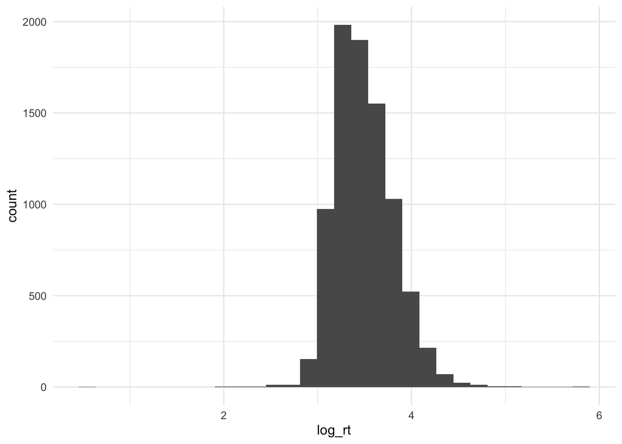

```r
df_merged_joined_correct %>%
  ggplot(aes(x = log_rt)) +
  geom_histogram() +
  theme_minimal()
```

### `Log(RT) ~ IsJoke`?

Yes, people are slower for *jokes*.

```r
mod_isjoke = lmer(data = df_merged_joined_correct,
                log_rt ~ IsJoke +
                  (1 | ParticipantID) +
                  (1 | Sentence),
                REML = FALSE)

mod_null= lmer(data = df_merged_joined_correct,
                log_rt ~ # IsJoke +
                  (1 | ParticipantID) +
                  (1 | Sentence),
                REML = FALSE)

summary(mod_isjoke)
```

```
## Linear mixed model fit by maximum likelihood . t-tests use Satterthwaite's
##   method [lmerModLmerTest]
## Formula: log_rt ~ IsJoke + (1 | ParticipantID) + (1 | Sentence)
##    Data: df_merged_joined_correct
##
##      AIC      BIC   logLik deviance df.resid
##   1075.3   1110.6   -532.7   1065.3     8476
##
## Scaled residuals:
##      Min       1Q   Median       3Q      Max
## -10.4882  -0.6279  -0.1157   0.5286   8.7579
##
## Random effects:
##  Groups        Name        Variance Std.Dev.
##  Sentence      (Intercept) 0.01518  0.1232
##  ParticipantID (Intercept) 0.02850  0.1688
##  Residual                  0.05728  0.2393
## Number of obs: 8481, groups:  Sentence, 400; ParticipantID, 158
##
## Fixed effects:
##              Estimate Std. Error        df t value Pr(>|t|)
## (Intercept)   3.49183    0.01596 268.17634 218.793  < 2e-16 ***
## IsJokeTRUE    0.06768    0.01384 392.09924   4.889 1.48e-06 ***
## ---
## Signif. codes:  0 '***' 0.001 '**' 0.01 '*' 0.05 '.' 0.1 ' ' 1
##
## Correlation of Fixed Effects:
##            (Intr)
## IsJokeTRUE -0.336
```

```r
anova(mod_isjoke, mod_null)
```

```
## Data: df_merged_joined_correct
## Models:
## mod_null: log_rt ~ (1 | ParticipantID) + (1 | Sentence)
## mod_isjoke: log_rt ~ IsJoke + (1 | ParticipantID) + (1 | Sentence)
##            npar    AIC    BIC  logLik deviance  Chisq Df Pr(>Chisq)
## mod_null      4 1096.5 1124.7 -544.28   1088.5
## mod_isjoke    5 1075.3 1110.6 -532.67   1065.3 23.213  1   1.45e-06 ***
## ---
## Signif. codes:  0 '***' 0.001 '**' 0.01 '*' 0.05 '.' 0.1 ' ' 1
```

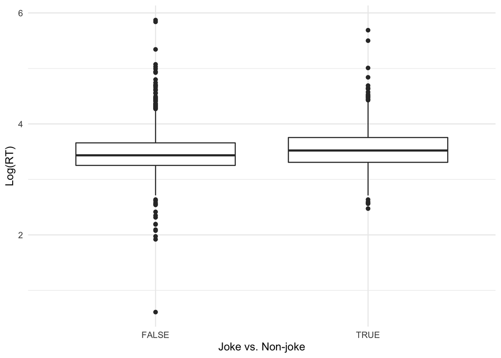

```r
df_merged_joined_correct %>%
  ggplot(aes(x = IsJoke,
             y = log_rt)) +
  geom_boxplot() +
  theme_minimal() +
  labs(x = "Joke vs. Non-joke",
       y = "Log(RT)")
```

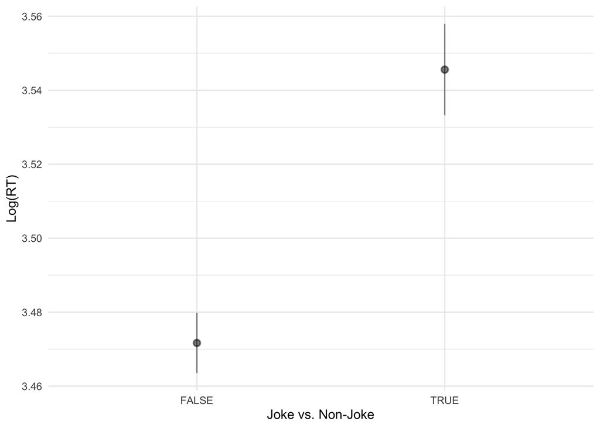

```r
df_merged_joined_correct %>%
  ggplot(aes(x = reorder(IsJoke, log_rt),
             y = log_rt)) +
  stat_summary (fun = function(x){mean(x)},
                fun.min = function(x){mean(x) - 2*sd(x)/sqrt(length(x))},
                fun.max = function(x){mean(x) + 2*sd(x)/sqrt(length(x))},
                geom= 'pointrange',
                position=position_dodge(width=0.95),
                size = .5, alpha = .5) +
  labs(x = "Joke vs. Non-Joke",
       y = "Log(RT)") +
  # scale_y_continuous(limits = c(0, 1)) +
  # geom_hline(yintercept = .5, linetype = "dotted") +
  theme_minimal()
```

### `Log(RT) ~ abs(Log-odds)`?

We can treat `abs(lp_ratio)` as a rough measure of LLM “confidence”: i.e., the further Log-odds is from zero, the more the LLM preferred one response to the other.

Indeed, as `abs(lp_ratio)` increases, RT also decreases.

```r
df_merged_joined_correct = df_merged_joined_correct %>%
  mutate(abs_lp = abs(lp_ratio))

mod_lp = lmer(data = df_merged_joined_correct,
                log_rt ~ abs_lp +
                  (1 | ParticipantID) +
                  (1 | Sentence),
                REML = FALSE)

anova(mod_lp, mod_null)
```

```
## Data: df_merged_joined_correct
## Models:
## mod_null: log_rt ~ (1 | ParticipantID) + (1 | Sentence)
## mod_lp: log_rt ~ abs_lp + (1 | ParticipantID) + (1 | Sentence)
##          npar    AIC    BIC  logLik deviance  Chisq Df Pr(>Chisq)
## mod_null    4 1096.5 1124.7 -544.28   1088.5
## mod_lp      5 1043.7 1079.0 -516.86   1033.7 54.828  1  1.315e-13 ***
## ---
## Signif. codes:  0 '***' 0.001 '**' 0.01 '*' 0.05 '.' 0.1 ' ' 1
```

```r
summary(mod_lp)
```

```
## Linear mixed model fit by maximum likelihood . t-tests use Satterthwaite's
##   method [lmerModLmerTest]
## Formula: log_rt ~ abs_lp + (1 | ParticipantID) + (1 | Sentence)
##    Data: df_merged_joined_correct
##
##      AIC      BIC   logLik deviance df.resid
##   1043.7   1079.0   -516.9   1033.7     8476
##
## Scaled residuals:
##      Min       1Q   Median       3Q      Max
## -10.4945  -0.6322  -0.1160   0.5242   8.7202
##
## Random effects:
##  Groups        Name        Variance Std.Dev.
##  Sentence      (Intercept) 0.01372  0.1171
##  ParticipantID (Intercept) 0.02859  0.1691
##  Residual                  0.05729  0.2394
## Number of obs: 8481, groups:  Sentence, 400; ParticipantID, 158
##
## Fixed effects:
##               Estimate Std. Error         df t value Pr(>|t|)
## (Intercept)   3.607274   0.018947 419.392312 190.385  < 2e-16 ***
## abs_lp       -0.014803   0.001928 382.382695  -7.677 1.37e-13 ***
## ---
## Signif. codes:  0 '***' 0.001 '**' 0.01 '*' 0.05 '.' 0.1 ' ' 1
##
## Correlation of Fixed Effects:
##        (Intr)
## abs_lp -0.616
```

### `Log(RT) ~ abs(Log-odds) + IsJoke`?

Now, we account for each of those covariates in assessing the other. Both explain independent variance.

```r
mod_both = lmer(data = df_merged_joined_correct,
                log_rt ~ abs_lp + IsJoke +
                  (1 | ParticipantID) +
                  (1 | Sentence),
                REML = FALSE)

anova(mod_both, mod_isjoke)
```

```
## Data: df_merged_joined_correct
## Models:
## mod_isjoke: log_rt ~ IsJoke + (1 | ParticipantID) + (1 | Sentence)
## mod_both: log_rt ~ abs_lp + IsJoke + (1 | ParticipantID) + (1 | Sentence)
##            npar    AIC    BIC  logLik deviance  Chisq Df Pr(>Chisq)
## mod_isjoke    5 1075.3 1110.6 -532.67   1065.3
## mod_both      6 1039.7 1081.9 -513.83   1027.7 37.683  1  8.322e-10 ***
## ---
## Signif. codes:  0 '***' 0.001 '**' 0.01 '*' 0.05 '.' 0.1 ' ' 1
```

```r
anova(mod_both, mod_lp)
```

```
## Data: df_merged_joined_correct
## Models:
## mod_lp: log_rt ~ abs_lp + (1 | ParticipantID) + (1 | Sentence)
## mod_both: log_rt ~ abs_lp + IsJoke + (1 | ParticipantID) + (1 | Sentence)
##          npar    AIC    BIC  logLik deviance  Chisq Df Pr(>Chisq)
## mod_lp      5 1043.7 1079.0 -516.86   1033.7
## mod_both    6 1039.7 1081.9 -513.83   1027.7 6.0681  1    0.01376 *
## ---
## Signif. codes:  0 '***' 0.001 '**' 0.01 '*' 0.05 '.' 0.1 ' ' 1
```

```r
summary(mod_both)
```

```
## Linear mixed model fit by maximum likelihood . t-tests use Satterthwaite's
##   method [lmerModLmerTest]
## Formula: log_rt ~ abs_lp + IsJoke + (1 | ParticipantID) + (1 | Sentence)
##    Data: df_merged_joined_correct
##
##      AIC      BIC   logLik deviance df.resid
##   1039.7   1081.9   -513.8   1027.7     8475
##
## Scaled residuals:
##      Min       1Q   Median       3Q      Max
## -10.4918  -0.6304  -0.1162   0.5267   8.7346
##
## Random effects:
##  Groups        Name        Variance Std.Dev.
##  Sentence      (Intercept) 0.01347  0.1161
##  ParticipantID (Intercept) 0.02859  0.1691
##  Residual                  0.05729  0.2394
## Number of obs: 8481, groups:  Sentence, 400; ParticipantID, 158
##
## Fixed effects:
##               Estimate Std. Error         df t value Pr(>|t|)
## (Intercept)   3.582449   0.021373 492.807749 167.614  < 2e-16 ***
## abs_lp       -0.012943   0.002056 382.451911  -6.294 8.47e-10 ***
## IsJokeTRUE    0.035026   0.014167 392.307838   2.472   0.0138 *
## ---
## Signif. codes:  0 '***' 0.001 '**' 0.01 '*' 0.05 '.' 0.1 ' ' 1
##
## Correlation of Fixed Effects:
##            (Intr) abs_lp
## abs_lp     -0.676
## IsJokeTRUE -0.469  0.366
```

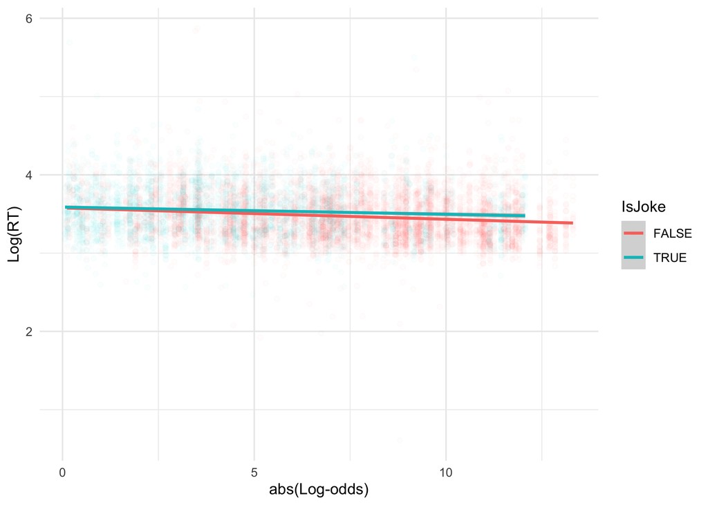

```r
df_merged_joined_correct %>%
  ggplot(aes(x = abs_lp,
      y = log_rt,
      color = IsJoke)) +
  geom_point(alpha = .02) +
  geom_smooth(method = "lm") +
  theme_minimal() +
  labs(x = "abs(Log-odds)",
       y = "Log(RT)")
```